# Social Media Engagement Analytics

# 6. Statistical modelling

We fit **log-linear** models, because the outcome variables are heavily right-skewed. Because the outcome is in $\log_{10}$, a coefficient of $\beta$ corresponds to a $(10^{\beta}-1)\times 100\%$ change.

- **Model A — engagement volume:** $\log_{10}(\text{Total Engagement})$ (likes + comments + shares + saves).
- **Model B — engagement efficiency:** $\log_{10}(\text{interactions per view})$.

> **Why not the supplied per-follower rate?** The supplied `Engagement_Rate` has followers in its denominator *and* follower count is a natural predictor, which creates a circular relationship that inflates the fit. We instead measure efficiency as **interactions per view**, which does not share the follower term with any predictor, giving an honest estimate.

Predictors in both: $\log_{10}$(followers), platform, content format, category, posting period, weekend flag, sentiment, hashtag count, $\log_{10}$(content length) and verification status.

```r
model_df <- readr::read_csv(file.path(DIR_PROC, "engagement_clean.csv"),
                            show_col_types = FALSE) %>%
  relevel_analysis() %>%
  mutate(
    log_engagement = log10(Total_Engagement),
    log_er_view    = log10(ER_by_Views)          # efficiency: interactions per view
  )

# --- Overall model formula (shared by A and the interaction model) -----------
fml_a <- log_engagement ~ log10(Follower_Count) + Platform + Content_Format +
  Category + Posting_Period + Is_Weekend + Sentiment +
  Hashtag_Count + log10(Content_Length) + Is_Verified

# --- Manual variance-inflation factors (no 'car' dependency) -----------------
vif_manual <- function(model) {
  X <- model.matrix(model)[, -1, drop = FALSE]
  v <- vapply(seq_len(ncol(X)), function(j) {
    r2 <- summary(stats::lm(X[, j] ~ X[, -j, drop = FALSE]))$r.squared
    1 / (1 - r2)
  }, numeric(1))
  tibble::tibble(term = colnames(X), VIF = round(v, 2))
}

# --- 5-fold cross-validation RMSE --------------------------------------------
cv_rmse <- function(form, data, response, k = 5, seed = 123) {
  set.seed(seed)
  folds <- sample(rep(seq_len(k), length.out = nrow(data)))
  fold_err <- vapply(seq_len(k), function(i) {
    tr <- data[folds != i, ]
    te <- data[folds == i, ]
    m  <- stats::lm(form, data = tr)
    sqrt(mean((te[[response]] - stats::predict(m, newdata = te))^2))
  }, numeric(1))
  mean(fold_err)
}
```

```r
model_a <- lm(fml_a, data = model_df)
glance_a <- broom::glance(model_a)
tidy_a   <- broom::tidy(model_a, conf.int = TRUE)
vif_a    <- vif_manual(model_a)

cat("==== MODEL A: log10(Total Engagement) ====\n")
```

```
## ==== MODEL A: log10(Total Engagement) ====
```

```r
print(glance_a)
```

```
## # A tibble: 1 × 12
##   r.squared adj.r.squared sigma statistic p.value    df logLik   AIC   BIC
##       <dbl>         <dbl> <dbl>     <dbl>   <dbl> <dbl>  <dbl> <dbl> <dbl>
## 1     0.686         0.684 0.244      374.       0    29  -23.6  109.  311.
## # ℹ 3 more variables: deviance <dbl>, df.residual <int>, nobs <int>
```

```r
std_df <- model_df %>%
  mutate(across(c(Total_Engagement, Follower_Count, Content_Length),
                ~ as.numeric(scale(log10(.x + 1))), .names = "z_{.col}"))
model_std <- lm(z_Total_Engagement ~ z_Follower_Count + Platform + Content_Format +
                  Category + Posting_Period + Is_Weekend + Sentiment +
                  Hashtag_Count + z_Content_Length + Is_Verified, data = std_df)
cat("\nStrongest standardised predictors (Model A):\n")
```

```
##
## Strongest standardised predictors (Model A):
```

```r
print(broom::tidy(model_std) %>% filter(term != "(Intercept)") %>%
        arrange(desc(abs(estimate))) %>% slice_head(n = 8) %>%
        mutate(across(where(is.numeric), ~ round(.x, 3))))
```

```
## # A tibble: 8 × 5
##   term                estimate std.error statistic p.value
##   <chr>                  <dbl>     <dbl>     <dbl>   <dbl>
## 1 PlatformTikTok         1.66      0.039     42.5    0
## 2 PlatformLinkedIn      -1.35      0.044    -30.7    0
## 3 PlatformYouTube        0.887     0.037     23.9    0
## 4 PlatformTwitter       -0.412     0.04     -10.3    0
## 5 PlatformFacebook      -0.096     0.028     -3.41   0.001
## 6 CategoryLifestyle      0.092     0.039      2.34   0.019
## 7 CategoryFitness        0.058     0.04       1.44   0.151
## 8 Posting_PeriodNight    0.057     0.021      2.74   0.006
```

```r
# Efficiency metric = interactions per view. Follower count does NOT appear in
# the denominator, so it is a legitimate predictor here (unlike the supplied
# per-follower Engagement_Rate, which would create circularity).
model_b <- lm(log_er_view ~ log10(Follower_Count) + Platform + Content_Format +
                Category + Posting_Period + Is_Weekend + Sentiment +
                Hashtag_Count + log10(Content_Length) + Is_Verified,
              data = model_df)
glance_b <- broom::glance(model_b)
tidy_b   <- broom::tidy(model_b, conf.int = TRUE)

cat("\n==== MODEL B: log10(interactions per view) ====\n")
```

```
##
## ==== MODEL B: log10(interactions per view) ====
```

```r
print(glance_b)
```

```
## # A tibble: 1 × 12
##   r.squared adj.r.squared sigma statistic   p.value    df logLik   AIC   BIC
##       <dbl>         <dbl> <dbl>     <dbl>     <dbl> <dbl>  <dbl> <dbl> <dbl>
## 1     0.225         0.221 0.460      49.9 1.34e-249    29 -3193. 6447. 6649.
## # ℹ 3 more variables: deviance <dbl>, df.residual <int>, nobs <int>
```

```r
model_int <- lm(update(fml_a, . ~ . + Platform:Content_Format), data = model_df)
glance_int <- broom::glance(model_int)
int_test   <- anova(model_a, model_int, test = "F")

cat("\n==== MODEL A + Platform x Content_Format interaction ====\n")
```

```
##
## ==== MODEL A + Platform x Content_Format interaction ====
```

```r
print(glance_int)
```

```
## # A tibble: 1 × 12
##   r.squared adj.r.squared sigma statistic p.value    df logLik   AIC   BIC
##       <dbl>         <dbl> <dbl>     <dbl>   <dbl> <dbl>  <dbl> <dbl> <dbl>
## 1     0.686         0.684 0.244      329.       0    33  -22.3  115.  343.
## # ℹ 3 more variables: deviance <dbl>, df.residual <int>, nobs <int>
```

```r
cat("\nNested F-test (interaction adds explanatory power?):\n")
```

```
##
## Nested F-test (interaction adds explanatory power?):
```

```r
print(int_test)
```

```
## Analysis of Variance Table
##
## Model 1: log_engagement ~ log10(Follower_Count) + Platform + Content_Format +
##     Category + Posting_Period + Is_Weekend + Sentiment + Hashtag_Count +
##     log10(Content_Length) + Is_Verified
## Model 2: log_engagement ~ log10(Follower_Count) + Platform + Content_Format +
##     Category + Posting_Period + Is_Weekend + Sentiment + Hashtag_Count +
##     log10(Content_Length) + Is_Verified + Platform:Content_Format
##   Res.Df    RSS Df Sum of Sq      F Pr(>F)
## 1   4970 295.53
## 2   4966 295.37  4   0.16172 0.6797 0.6059
```

```r
set.seed(123)
cv_a <- cv_rmse(fml_a, model_df, "log_engagement")
cv_b <- cv_rmse(log_er_view ~ log10(Follower_Count) + Platform + Content_Format +
                  Category + Posting_Period + Is_Weekend + Sentiment +
                  Hashtag_Count + log10(Content_Length) + Is_Verified,
                model_df, "log_er_view")
cat(sprintf("\n5-fold CV RMSE | Model A: %.3f | Model B: %.3f (log10 units)\n",
            cv_a, cv_b))
```

```
##
## 5-fold CV RMSE | Model A: 0.244 | Model B: 0.461 (log10 units)
```

```r
# Exclude the 295 posts whose total engagement exceeds their view count and
# refit Model A to confirm the conclusions are not driven by those records.
model_df_clean <- model_df %>% filter(Reaches_Viewers)
model_a_clean  <- lm(fml_a, data = model_df_clean)
sens_compare <- tibble::tibble(
  Sample     = c("All posts", "Excluding view anomalies"),
  N          = c(nrow(model_df), nrow(model_df_clean)),
  Adj_R2     = round(c(glance_a$adj.r.squared, broom::glance(model_a_clean)$adj.r.squared), 3),
  TikTok_coef = round(c(coef(model_a)["PlatformTikTok"],
                        coef(model_a_clean)["PlatformTikTok"]), 3),
  LinkedIn_coef = round(c(coef(model_a)["PlatformLinkedIn"],
                          coef(model_a_clean)["PlatformLinkedIn"]), 3)
)
cat("\n==== SENSITIVITY: Model A on cleaned subset ====\n")
```

```
##
## ==== SENSITIVITY: Model A on cleaned subset ====
```

```r
print(sens_compare)
```

```
## # A tibble: 2 × 5
##   Sample                       N Adj_R2 TikTok_coef LinkedIn_coef
##   <chr>                    <int>  <dbl>       <dbl>         <dbl>
## 1 All posts                 5000  0.684       0.718        -0.584
## 2 Excluding view anomalies  4705  0.685       0.734        -0.563
```

```r
model_text <- c(
  "==== MODEL A: log10(Total Engagement) ~ predictors ====",
  capture.output(print(glance_a)),
  "",
  "---- Coefficients (Model A) ----",
  capture.output(print(as.data.frame(tidy_a %>% mutate(across(where(is.numeric), ~ round(.x, 4)))) %>%
                         select(term, estimate, std.error, statistic, p.value, conf.low, conf.high))),
  "",
  sprintf("Max VIF (Model A): %.2f", max(vif_a$VIF)),
  capture.output(print(as.data.frame(vif_a %>% filter(VIF > 5)))),
  "",
  "==== MODEL B: log10(interactions per view) ~ predictors ====",
  capture.output(print(glance_b)),
  "",
  "==== Model A + Platform x Content_Format interaction ====",
  capture.output(print(glance_int)),
  capture.output(print(int_test)),
  "",
  "==== 5-fold cross-validation ====",
  sprintf("RMSE Model A (log10): %.3f", cv_a),
  sprintf("RMSE Model B (log10): %.3f", cv_b),
  "",
  "==== Sensitivity (Model A, excluding view anomalies) ====",
  capture.output(print(sens_compare)),
  "",
  sprintf("Model A adjusted R-squared: %.3f", glance_a$adj.r.squared),
  sprintf("Model B adjusted R-squared: %.3f", glance_b$adj.r.squared),
  sprintf("Interaction model adjusted R-squared: %.3f", glance_int$adj.r.squared)
)
writeLines(model_text, file.path(DIR_PROC, "model_summary.txt"))
cat(paste(model_text, collapse = "\n"), "\n")
```

```
## ==== MODEL A: log10(Total Engagement) ~ predictors ====
## # A tibble: 1 × 12
##   r.squared adj.r.squared sigma statistic p.value    df logLik   AIC   BIC
##       <dbl>         <dbl> <dbl>     <dbl>   <dbl> <dbl>  <dbl> <dbl> <dbl>
## 1     0.686         0.684 0.244      374.       0    29  -23.6  109.  311.
## # ℹ 3 more variables: deviance <dbl>, df.residual <int>, nobs <int>
##
## ---- Coefficients (Model A) ----
##                          term estimate std.error statistic p.value conf.low
## 1                 (Intercept)   3.7279    0.0529   70.4745  0.0000   3.6242
## 2       log10(Follower_Count)  -0.0171    0.0081   -2.1105  0.0349  -0.0331
## 3              PlatformTikTok   0.7183    0.0169   42.5012  0.0000   0.6852
## 4            PlatformFacebook  -0.0417    0.0122   -3.4102  0.0007  -0.0657
## 5             PlatformYouTube   0.3846    0.0161   23.8820  0.0000   0.3530
## 6             PlatformTwitter  -0.1786    0.0174  -10.2817  0.0000  -0.2127
## 7            PlatformLinkedIn  -0.5840    0.0190  -30.6814  0.0000  -0.6213
## 8         Content_FormatImage  -0.0065    0.0130   -0.5003  0.6169  -0.0321
## 9   Content_FormatInteractive   0.0083    0.0142    0.5868  0.5573  -0.0194
## 10 Content_FormatText/Article   0.0169    0.0132    1.2762  0.2019  -0.0091
## 11          CategoryEducation   0.0046    0.0173    0.2626  0.7929  -0.0294
## 12      CategoryEntertainment   0.0169    0.0171    0.9876  0.3234  -0.0167
## 13            CategoryFashion   0.0207    0.0172    1.2038  0.2287  -0.0130
## 14            CategoryFitness   0.0252    0.0175    1.4353  0.1513  -0.0092
## 15               CategoryFood   0.0161    0.0173    0.9283  0.3533  -0.0179
## 16             CategoryGaming  -0.0004    0.0168   -0.0227  0.9819  -0.0333
## 17             CategoryHealth  -0.0028    0.0175   -0.1597  0.8732  -0.0371
## 18          CategoryLifestyle   0.0401    0.0171    2.3391  0.0194   0.0065
## 19             CategorySports   0.0246    0.0175    1.4111  0.1583  -0.0096
## 20         CategoryTechnology   0.0152    0.0171    0.8842  0.3766  -0.0184
## 21             CategoryTravel   0.0132    0.0175    0.7556  0.4499  -0.0211
## 22    Posting_PeriodAfternoon   0.0231    0.0099    2.3193  0.0204   0.0036
## 23      Posting_PeriodEvening   0.0172    0.0100    1.7219  0.0852  -0.0024
## 24        Posting_PeriodNight   0.0249    0.0091    2.7399  0.0062   0.0071
## 25             Is_WeekendTRUE  -0.0169    0.0077   -2.1971  0.0281  -0.0319
## 26           SentimentNeutral  -0.0003    0.0107   -0.0246  0.9804  -0.0212
## 27          SentimentPositive   0.0137    0.0102    1.3504  0.1770  -0.0062
## 28              Hashtag_Count   0.0004    0.0004    0.9134  0.3611  -0.0004
## 29      log10(Content_Length)   0.0076    0.0098    0.7726  0.4398  -0.0116
## 30    Is_VerifiedNot verified   0.0083    0.0079    1.0526  0.2926  -0.0071
##    conf.high
```

[output cut: 59 more lines]

```
##
## ==== 5-fold cross-validation ====
## RMSE Model A (log10): 0.244
## RMSE Model B (log10): 0.461
##
## ==== Sensitivity (Model A, excluding view anomalies) ====
## # A tibble: 2 × 5
##   Sample                       N Adj_R2 TikTok_coef LinkedIn_coef
##   <chr>                    <int>  <dbl>       <dbl>         <dbl>
## 1 All posts                 5000  0.684       0.718        -0.584
## 2 Excluding view anomalies  4705  0.685       0.734        -0.563
##
## Model A adjusted R-squared: 0.684
## Model B adjusted R-squared: 0.221
## Interaction model adjusted R-squared: 0.684
```

## 6.1 Coefficient plots

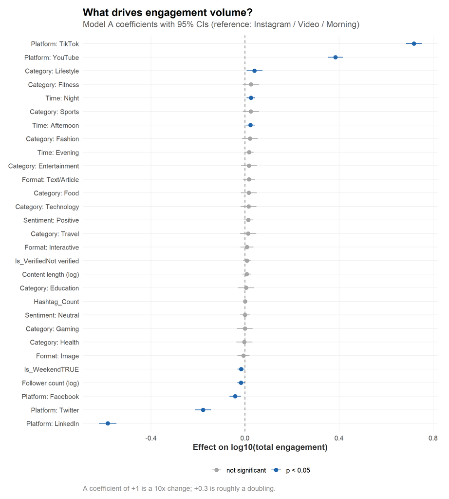

```r
make_coef_plot <- function(tidy_tbl, title, subtitle, xlab, caption) {
  d <- tidy_tbl %>%
    filter(term != "(Intercept)") %>%
    mutate(
      term = str_replace_all(term, "log10\\(Follower_Count\\)", "Follower count (log)"),
      term = str_replace_all(term, "log10\\(Content_Length\\)", "Content length (log)"),
      term = str_replace_all(term, "Platform", "Platform: "),
      term = str_replace_all(term, "Content_Format", "Format: "),
      term = str_replace_all(term, "Posting_Period", "Time: "),
      term = str_replace_all(term, "Sentiment", "Sentiment: "),
      term = str_replace_all(term, "Category", "Category: "),
      significant = p.value < 0.05,
      term = fct_reorder(term, estimate)
    )
  ggplot(d, aes(estimate, term, colour = significant)) +
    geom_vline(xintercept = 0, linetype = "dashed", colour = "grey50") +
    geom_pointrange(aes(xmin = conf.low, xmax = conf.high), size = 0.4) +
    scale_colour_manual(values = c(`TRUE` = "#2166AC", `FALSE` = "grey65"),
                        labels = c(`TRUE` = "p < 0.05", `FALSE` = "not significant"),
                        name = NULL) +
    labs(title = title, subtitle = subtitle, x = xlab, y = NULL, caption = caption)
}

fig_coef <- make_coef_plot(
  tidy_a,
  "What drives engagement volume?",
  "Model A coefficients with 95% CIs (reference: Instagram / Video / Morning)",
  "Effect on log10(total engagement)",
  "A coefficient of +1 is a 10x change; +0.3 is roughly a doubling."
)
save_plot(fig_coef, "fig09_modelA_coefficients", width = 9, height = 10)
print(fig_coef)
```

*Figure 9. Model A coefficients with 95% confidence intervals. Platform dominates; content format and category are mostly insignificant for volume.*

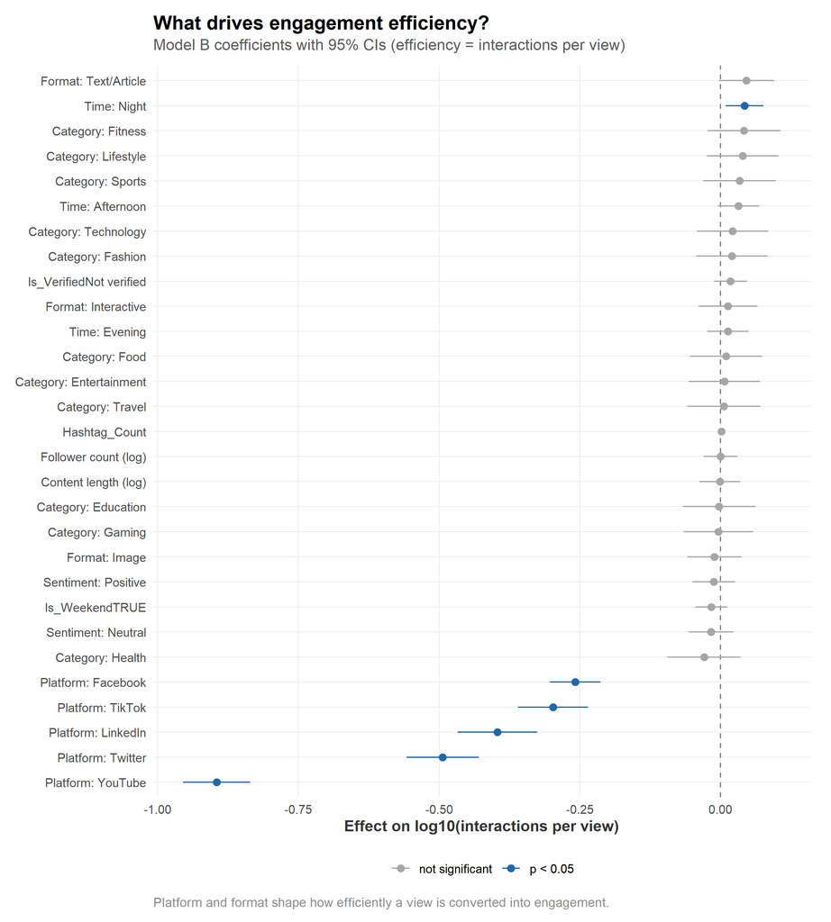

```r
fig_coef_b <- make_coef_plot(
  tidy_b,
  "What drives engagement efficiency?",
  "Model B coefficients with 95% CIs (efficiency = interactions per view)",
  "Effect on log10(interactions per view)",
  "Platform and format shape how efficiently a view is converted into engagement."
)
save_plot(fig_coef_b, "fig10_modelB_efficiency_coefficients", width = 9, height = 10)
print(fig_coef_b)
```

## 6.2 Does platform interact with format?

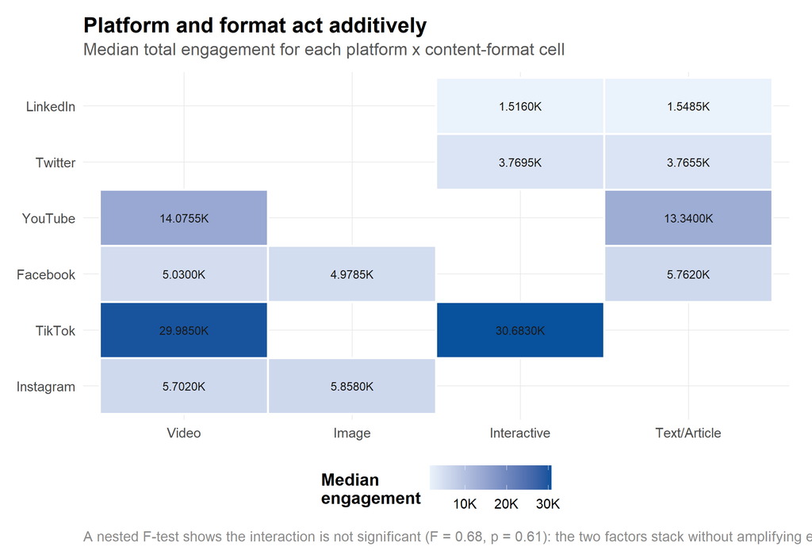

```r
inter_df <- model_df %>%
  group_by(Platform, Content_Format) %>%
  summarise(Median_Eng = median(Total_Engagement), .groups = "drop")

fig_int <- ggplot(inter_df, aes(Content_Format, Platform, fill = Median_Eng)) +
  geom_tile(colour = "white", linewidth = 0.7) +
  geom_text(aes(label = comma_short(Median_Eng)), size = 2.9, colour = "grey10") +
  scale_fill_gradient(low = "#EAF2FB", high = "#08519C", labels = comma_short) +
  labs(
    title = "Platform and format act additively",
    subtitle = "Median total engagement for each platform x content-format cell",
    x = NULL, y = NULL, fill = "Median\nengagement",
    caption = "A nested F-test shows the interaction is not significant (F = 0.68, p = 0.61): the two factors stack without amplifying each other."
  )
save_plot(fig_int, "fig11_platform_format_interaction", width = 8, height = 5.5)
print(fig_int)
```

*Figure 11. Median engagement for each platform × content-format cell. A nested F-test (F = 0.68, p = 0.61) shows the interaction is **not** significant: platform and format act additively rather than amplifying one another, so the simpler additive Model A is preferred.*

## 6.3 Model selection and robustness

We compare models with adjusted $R^2$, AIC/BIC (in §6 output) and **5-fold cross-validation**, and re-fit Model A after removing data-quality anomalies (results printed in §6’s output block above).

Cross-validated RMSE confirms Model A generalises well: 0.244 on the $\log_{10}$ scale, i.e. a typical out-of-sample multiplicative error of about $\times 1.76$. The sensitivity check shows the coefficients barely move when the 295 view-anomaly posts are excluded (TikTok 0.72 → 0.73; LinkedIn −0.58 → −0.56; adjusted $R^2$ 0.684 → 0.685), so no conclusion depends on the anomalies.